# Modeling in `Spark` with `sparklyr`

# 1 Learning Objectives

- Get more experience of data wrangling in `Spark`
- Experience basic feature engineering in `Spark`, including `ft_` objects from `MLlib`
- Deploy train-test splitting
- Fit a logistic regression model in `Spark`
- Test the model on the test set

**Lesson Duration: 90 mins**

# 2 Loading and exploring data

## 2.1 Connecting and loading

You know the drill by now! Let’s load `sparklyr` and connect to the local `Spark` installation:

```r
library(sparklyr)
sc <- spark_connect(master = "local")
```

The dataset we’re going to be working on in this lesson comes from the `OkCupid` website and comprises a reasonably large range of user profiles. Our modeling aim is to use the data to build a predictive model of whether a user `not_working`: we are going to have to create this variable ourselves. Let’s load the data into `Spark`:

```r
library(tidyverse)
profiles <- spark_read_csv(
  sc,
  "data/profiles.csv",
  escape = "\"",
  memory = FALSE,
  options = list(multiline = TRUE)
)

glimpse(profiles)
```

```
## Rows: ??
## Columns: 31
## Database: spark_connection
## $ age         <int> 47, 27, 45, 40, 33, 27, 20, 28, 24, 34, 32, 23, 19, 45, 3…
## $ body_type   <chr> "athletic", "full figured", NA, "athletic", "athletic", "…
## $ diet        <chr> "mostly anything", "mostly vegetarian", NA, NA, "mostly a…
## $ drinks      <chr> "socially", "socially", "socially", "socially", "rarely",…
## $ drugs       <chr> "never", NA, "never", "never", "never", "sometimes", "nev…
## $ education   <chr> "graduated from college/university", "graduated from coll…
## $ essay0      <chr> NA, "still figuring out what to put here... for now i'll …
## $ essay1      <chr> "working in a creative industry (brand marketing agency),…
## $ essay2      <chr> "listening to people, hearing them and working to help th…
## $ essay3      <chr> "my million dollar smile (self-deprecating humor).", "my …
## $ essay4      <chr> "sadly, my reading is confined to newspapers and business…
## $ essay5      <chr> "my daughter. usa today. exercise. some travel. world new…
```

[output cut: 19 more lines]

We set `memory = FALSE, options = list(multiline = TRUE)` to deal with the parts of the essays, which have been loaded in 10 fields `essay0` to `essay9`.

## 2.2 Checking for `NA`s and other odd values

Let’s see how many `NA`s we have in the various columns:

```r
profiles %>%
  summarise_all(.funs = ~ sum(as.integer(is.na(.))))
```

| age | body_type | diet | drinks | drugs | education | essay0 | essay1 | essay2 | essay3 | essay4 | essay5 | essay6 | essay7 | essay8 | essay9 | ethnicity | height | income | job | last_online | location | offspring | orientation | pets | religion | sex | sign | smokes | speaks | … |
| --- | --- | --- | --- | --- | --- | --- | --- | --- | --- | --- | --- | --- | --- | --- | --- | --- | --- | --- | --- | --- | --- | --- | --- | --- | --- | --- | --- | --- | --- | --- |
| 0 | 1064 | 4867 | 615 | 2702 | 1279 | 1082 | 1451 | 1985 | 2295 | 2093 | 2150 | 2780 | 2502 | 3840 | 2490 | 1121 | 0 | 0 | 1572 | 0 | 0 | 7153 | 0 | 3955 | 4015 | 0 | 2147 | 1121 | 7 | … |

Note here we had to use `as.integer()` because of the **statically typed** nature of `Spark`. If we ran `show_query()` on the pipe above we we would find parts of the form `SUM(CAST(((age) IS NULL) AS INT)) AS age`, which make clear we are type-converting logical type to integer. If we try to leave out `as.integer()` we will get a typing error:

```r
profiles %>%
  summarise_all(.funs = ~ sum(is.na(.)))
```

[output not shown]

[output cut: 28 more lines]

[output not shown]

We see that the majority of the columns have a significant number of `NA`s. We also saw from the `glimpse()` of the data set above that we had some negative incomes. Let’s see how many:

```r
profiles %>%
  summarise(num_neg_income = sum(as.integer(income < 0)))
```

| num_neg_income |
| --- |
| 9596 |

We’ll clean up our data. Some `Spark` operations are easier if missing values in categorical columns are explicitly labelled as missing, so let’s split our `profiles` into `character` and `numeric` sections and deal with them separately. First, the `character` section:

```r
profiles_char <- profiles %>%
  select(-c(age, income, height)) %>%
  mutate_all(~ ifelse(is.na(.), "missing", .))
```

and now we’ll deal with the numeric part, converting `age` and `height` to `numeric` (which `Spark` will see as `DoubleType`), and inserting proper `NA`s into `income` in place of negative values:

```r
profiles_num <- profiles %>%
  select(age, income, height) %>%
  mutate(
    age = as.numeric(age),
    income = ifelse(income == "-1", NA, as.numeric(income)),
    height = as.numeric(height)
  )
```

Finally, we bind the columns of the two sections together and `compute()` the result:

```r
profiles <- sdf_bind_cols(profiles_char, profiles_num) %>%
  compute("profiles") %>%
  glimpse()
```

```
## Rows: ??
## Columns: 31
## Database: spark_connection
## $ body_type   <chr> "thin", "curvy", "average", "fit", "athletic", "curvy", "…
## $ diet        <chr> "mostly anything", "mostly anything", "strictly anything"…
## $ drinks      <chr> "socially", "socially", "often", "socially", "often", "so…
## $ drugs       <chr> "sometimes", "never", "sometimes", "never", "sometimes", …
## $ education   <chr> "working on masters program", "working on college/univers…
## $ essay0      <chr> "grad student at berkeley. i am moving to sf pretty soon …
## $ essay1      <chr> "doing my mba at berkeley and working part time. i also t…
## $ essay2      <chr> "missing", "music. english. chemistry. dancing.", "drinki…
## $ essay3      <chr> "i look younger than i am..", "my smile, because i am pre…
## $ essay4      <chr> "music: wow where do i start? radiohead, led zeppelin, pi…
## $ essay5      <chr> "- inspiring people<br />\n- swimming<br />\n- great food…
## $ essay6      <chr> "- how crazy life is<br />\n- finding a guy just like you…
```

[output cut: 19 more lines]

Now let’s check again for the troublesome values we found earlier:

```r
profiles %>%
  summarise_all(~sum(as.integer(is.na(.))))
```

| body_type | diet | drinks | drugs | education | essay0 | essay1 | essay2 | essay3 | essay4 | essay5 | essay6 | essay7 | essay8 | essay9 | ethnicity | job | last_online | location | offspring | orientation | pets | religion | sex | sign | smokes | speaks | status | age | income | … |
| --- | --- | --- | --- | --- | --- | --- | --- | --- | --- | --- | --- | --- | --- | --- | --- | --- | --- | --- | --- | --- | --- | --- | --- | --- | --- | --- | --- | --- | --- | --- |
| 0 | 0 | 0 | 0 | 0 | 0 | 0 | 0 | 0 | 0 | 0 | 0 | 0 | 0 | 0 | 0 | 0 | 0 | 0 | 0 | 0 | 0 | 0 | 0 | 0 | 0 | 0 | 0 | 0 | 9596 | … |

```r
profiles %>%
  summarise(num_neg_income = sum(as.integer(income < 0)))
```

| num_neg_income |
| --- |
| 0 |

This looks better! The `NA`s in `income` have to remain for now, if we wanted to use this variable later, we would either need to drop these rows or use imputation. Finally, let’s check the schema of `profiles`:

```r
schema <- sdf_schema(profiles)

schema <- schema %>%
  transpose() %>%
  as_tibble() %>%
  unnest(cols = c(name, type))

schema
```

| name | type |
| --- | --- |
| body_type | StringType |
| diet | StringType |
| drinks | StringType |
| drugs | StringType |
| education | StringType |
| essay0 | StringType |
| essay1 | StringType |
| essay2 | StringType |
| essay3 | StringType |
| essay4 | StringType |

[output cut: 21 more lines]

## 2.3 Exploring categoricals: cross-tabulation

We suspect that people less likely to regularly drink are also less likely to regularly use drugs, let’s confirm this with a cross-tabulation (also known as a contingency table):

```r
contingency <- profiles %>%
  sdf_crosstab("drinks", "drugs") %>%
  collect()

contingency
```

| drinks_drugs | missing | never | often | sometimes |
| --- | --- | --- | --- | --- |
| very often | 13 | 46 | 13 | 38 |
| socially | 1944 | 5329 | 38 | 989 |
| not at all | 44 | 553 | 5 | 20 |
| desperately | 15 | 21 | 3 | 18 |
| often | 260 | 411 | 12 | 319 |
| missing | 280 | 314 | 3 | 18 |
| rarely | 146 | 906 | 13 | 109 |

The contingency table is nice, but it would be better to order the levels of `drinks` and `drugs` to aid comparisons. Now that we’ve collected the `contingency` tibble, we can do this using standard `dplyr` operations:

```r
contingency %>%
  rename(drinks = drinks_drugs) %>%
  mutate(
    drinks = as_factor(drinks) %>%
      fct_relevel("missing", "not at all", "rarely", "socially", "often",
                  "very often", "desperately")
  ) %>%
  arrange(drinks) %>%
  select(drinks, missing, never, sometimes, often)
```

| drinks | missing | never | sometimes | often |
| --- | --- | --- | --- | --- |
| missing | 280 | 314 | 18 | 3 |
| not at all | 44 | 553 | 20 | 5 |
| rarely | 146 | 906 | 109 | 13 |
| socially | 1944 | 5329 | 989 | 38 |
| often | 260 | 411 | 319 | 12 |
| very often | 13 | 46 | 38 | 13 |
| desperately | 15 | 21 | 18 | 3 |

## 2.4 Adding the response variable

Now we add in the `not_working` response variable:

```r
profiles <- profiles %>%
  mutate(
    not_working = as.integer(ifelse(job %in% c("student", "unemployed", "retired"), 1, 0))
  )

profiles %>%
  count(not_working)
```

| not_working | n |
| --- | --- |
| 0 | 10775 |
| 1 | 1105 |

So we have a fairly imbalanced data set, but that’s OK, we just need to keep it in mind.

Finally, if we want to see enhanced information for the `numerical` variables, we can use the `sdf_describe()` function:

```r
sdf_describe(profiles, cols = c("age", "height", "income", "not_working"))
```

| summary | age | height | income | not_working |
| --- | --- | --- | --- | --- |
| count | 11880 | 11880 | 2284 | 11880 |
| mean | 32.13644781144781 | 68.2959595959596 | 99251.31348511383 | 0.09301346801346802 |
| stddev | 9.289272390163378 | 4.008613149266241 | 189782.84815843875 | 0.2904635339499371 |
| min | 18.0 | 1.0 | 20000.0 | 0 |
| max | 69.0 | 95.0 | 1000000.0 | 1 |

# 3 Feature engineering

## 3.1 Religion: extracting words

Let’s see the distinct levels of the `religion` variable:

```r
profiles %>%
  distinct(religion)
```

| religion |
| --- |
| judaism |
| judaism and laughing about it |
| atheism |
| christianity but not too serious about it |
| buddhism and laughing about it |
| christianity |
| atheism and very serious about it |
| judaism and somewhat serious about it |
| atheism and somewhat serious about it |
| islam and very serious about it |

[output cut: 36 more lines]

Hmm, 46 levels is likely too many, but on scanning the results above, we could make `religion` more useful by wrangling the first word out of the levels. Let’s do that vi a `regex` and the `Spark SQL` `regexp_extract()` function:

```r
profiles <- profiles %>%
  mutate(religion = regexp_extract(religion, "[a-zA-Z]+", 0)) %>%
  compute("profiles") %>%
  glimpse()
```

```
## Rows: ??
## Columns: 32
## Database: spark_connection
## $ body_type   <chr> "thin", "curvy", "average", "fit", "athletic", "curvy", "…
## $ diet        <chr> "mostly anything", "mostly anything", "strictly anything"…
## $ drinks      <chr> "socially", "socially", "often", "socially", "often", "so…
## $ drugs       <chr> "sometimes", "never", "sometimes", "never", "sometimes", …
## $ education   <chr> "working on masters program", "working on college/univers…
## $ essay0      <chr> "grad student at berkeley. i am moving to sf pretty soon …
## $ essay1      <chr> "doing my mba at berkeley and working part time. i also t…
## $ essay2      <chr> "missing", "music. english. chemistry. dancing.", "drinki…
## $ essay3      <chr> "i look younger than i am..", "my smile, because i am pre…
## $ essay4      <chr> "music: wow where do i start? radiohead, led zeppelin, pi…
## $ essay5      <chr> "- inspiring people<br />\n- swimming<br />\n- great food…
## $ essay6      <chr> "- how crazy life is<br />\n- finding a guy just like you…
```

[output cut: 20 more lines]

Now let’s see if the proportion of users `not_working` varies significantly with our simplified `religion` variable:

```r
profiles %>%
  count(religion, not_working) %>%
  group_by(religion) %>%
  summarise(
    count = sum(n),
    prop_not_working = sum(not_working * n) / sum(n)
  )
```

| religion | count | prop_not_working |
| --- | --- | --- |
| judaism | 587 | 0.07495741 |
| atheism | 1386 | 0.12121212 |
| christianity | 1150 | 0.12695652 |
| missing | 4015 | 0.07372354 |
| hinduism | 92 | 0.08695652 |
| other | 1552 | 0.08440722 |
| buddhism | 386 | 0.09844560 |
| islam | 32 | 0.25000000 |
| agnosticism | 1711 | 0.09526593 |
| catholicism | 969 | 0.10629515 |

## 3.2 Essays: extracting total length

Let’s also get the length of the essays written by the users. We’re going to use a little bit of **tidy evaluation** to do this. We haven’t really had a chance to cover this on the course, as it is an advanced topic, but it is very useful. We recommend following the tutorial [here](https://rstudio.com/resources/webinars/tidy-evaluation-is-one-of-the-major-feature-of-the-latest-versions-of-dplyr-and-tidyr/) to find out more!

We use the `syms()` function and `!!!` operator from `tidy eval` to do this:

```r
profiles <- profiles %>%
  mutate(
    essay_length = char_length(paste(!!!syms(paste0("essay", 0:9))))
  ) %>%
  compute("profiles") %>%
  glimpse()
```

```
## Rows: ??
## Columns: 33
## Database: spark_connection
## $ body_type    <chr> "thin", "curvy", "average", "fit", "athletic", "curvy", …
## $ diet         <chr> "mostly anything", "mostly anything", "strictly anything…
## $ drinks       <chr> "socially", "socially", "often", "socially", "often", "s…
## $ drugs        <chr> "sometimes", "never", "sometimes", "never", "sometimes",…
## $ education    <chr> "working on masters program", "working on college/univer…
## $ essay0       <chr> "grad student at berkeley. i am moving to sf pretty soon…
## $ essay1       <chr> "doing my mba at berkeley and working part time. i also …
## $ essay2       <chr> "missing", "music. english. chemistry. dancing.", "drink…
## $ essay3       <chr> "i look younger than i am..", "my smile, because i am pr…
## $ essay4       <chr> "music: wow where do i start? radiohead, led zeppelin, p…
## $ essay5       <chr> "- inspiring people<br />\n- swimming<br />\n- great foo…
## $ essay6       <chr> "- how crazy life is<br />\n- finding a guy just like yo…
```

[output cut: 21 more lines]

## 3.3 Converting categoricals to dummies

Imagine we decide that our model is going to involve categorical variables `drinks`, `drugs` and `status`. We can use a number of `ft_` functions to convert each categorical variable to dummy columns. The pattern is always the same: we ‘index’ each variable and then ‘encode’ it:

```r
profiles <- profiles %>%
    ft_string_indexer(
    input_col = "drinks",
    output_col = "drinks_indexed"
  ) %>%
  ft_one_hot_encoder(
    input_cols = "drinks_indexed",
    output_cols = "drinks_encoded"
  ) %>%
  ft_string_indexer(
    input_col = "drugs",
    output_col = "drugs_indexed"
  ) %>%
  ft_one_hot_encoder(
    input_cols = "drugs_indexed",
    output_cols = "drugs_encoded"
  ) %>%
  ft_string_indexer(
    input_col = "status",
    output_col = "status_indexed"
  ) %>%
  ft_one_hot_encoder(
    input_cols = "status_indexed",
    output_cols = "status_encoded"
  ) %>%
  compute("profiles")
```

But what do these functions `ft_string_indexer()` and `ft_one_hot_encoder()` do? Let’s find out:

> **Task - 5 mins**

> We’re going to look at the `drinks` related columns we now have in `profiles`. Select the original `drinks` column, together with the `drinks_indexed` and `drinks_encoded` columns we added above and look at a few rows (`glimpse()` or `head()`):
> - Can you see how the columns are related?
> - What is stored in the `drinks_encoded` column?

> **Solution**

> ```r
> profiles %>%
>   select(starts_with("drinks")) %>%
>   glimpse()
> ```

> ```
> ## Rows: ??
> ## Columns: 3
> ## Database: spark_connection
> ## $ drinks         <chr> "socially", "socially", "often", "socially", "often", …
> ## $ drinks_indexed <dbl> 0, 0, 2, 0, 2, 0, 0, 0, 0, 0, 0, 0, 0, 0, 0, 4, 1, 1, …
> ## $ drinks_encoded <list> [<1, 0, 0, 0, 0, 0>, <1, 0, 0, 0, 0, 0>, <0, 0, 1, 0,…
> ```

> - `drinks_indexed` takes the levels of `drinks` and maps them to an index number (0 being the most common level, 1 the next most common, and so on). `drinks_encoded` takes the `drinks_indexed` values and maps them to dummy columns (dropping the last level).
> - `drinks_encoded` is in the form of a **vector column** - i.e. a column containing vectors.

## 3.4 Train-test splitting

Let’s use `sdf_random_split()` to partition `profiles` into `training` and `testing` sets:

```r
# For reproducibility purposes we're using a seed here. Don't do this in real applications.
partitioned <- profiles %>%
  sdf_random_split(training = 0.7, testing = 0.3, seed = 42)

training <- partitioned$training %>%
  compute("training")

testing <- partitioned$testing %>%
  compute("testing")
```

```r
profiles %>%
  sdf_describe("not_working")
```

| summary | not_working |
| --- | --- |
| count | 11880 |
| mean | 0.09301346801346802 |
| stddev | 0.2904635339499371 |
| min | 0 |
| max | 1 |

We can use the `sdf_describe()` function to check the relative proportions of `not_working` in `profiles`, `training` and `testing` for consistency:

```r
training %>%
  sdf_describe("not_working")
```

| summary | not_working |
| --- | --- |
| count | 8305 |
| mean | 0.09247441300421433 |
| stddev | 0.2897119297949364 |
| min | 0 |
| max | 1 |

```r
testing %>%
  sdf_describe("not_working")
```

| summary | not_working |
| --- | --- |
| count | 3575 |
| mean | 0.09426573426573427 |
| stddev | 0.2922389343097223 |
| min | 0 |
| max | 1 |

These look reasonably similar.

## 3.5 Age and essay length: manual variable scaling

Finally, let’s see how to scale variables manually. We’re going to scale the `age` and `essay_length` variables. First we get the means and standard deviations:

```r
scaling_values <- training %>%
  summarize(
    mean_age = mean(age),
    sd_age = sd(age),
    mean_essay_length = mean(essay_length),
    sd_essay_length = sd(essay_length)
  ) %>%
  collect()
scaling_values
```

| mean_age | sd_age | mean_essay_length | sd_essay_length |
| --- | --- | --- | --- |
| 32.1103 | 9.278506 | 2209.296 | 2005.776 |

Next we mutate to create `scaled_age` and `scaled_essay_length` features. Now, if we try the following:

```r
training %>%
  mutate(
    scaled_age = (age - scaling_values$mean_age) / scaling_values$sd_age,
    scaled_essay_length = (essay_length - scaling_values$mean_essay_length ) / scaling_values$sd_essay_length
  ) %>%
  glimpse()
```

```
## Error: Cannot embed a data frame in a SQL query.
##
## If you are seeing this error in code that used to work, the most likely
## cause is a change dbplyr 1.4.0. Previously `df$x` or `df[[y]]` implied
## that `df` was a local variable, but now you must make that explict with
## `!!` or `local()`, e.g., `!!df$x` or `local(df[["y"]])
```

we’ll see an error telling us we need to pass in the values from `scaling_values` by placing a `!!` in front of them:

```r
training <- training %>%
  mutate(
    scaled_age = (age - !!scaling_values$mean_age) / !!scaling_values$sd_age,
    scaled_essay_length = (essay_length - !!scaling_values$mean_essay_length ) / !!scaling_values$sd_essay_length
  )
```

Let’s check it worked:

```r
training %>%
  select(age, scaled_age, essay_length, scaled_essay_length) %>%
  glimpse()
```

```
## Rows: ??
## Columns: 4
## Database: spark_connection
## $ age                 <dbl> 29, 45, 26, 20, 20, 26, 32, 26, 31, 36, 34, 36, 3…
## $ scaled_age          <dbl> -0.33521506, 1.38920047, -0.65854297, -1.30519880…
## $ essay_length        <int> 892, 4240, 2945, 2055, 2746, 1837, 2681, 560, 976…
## $ scaled_essay_length <dbl> -0.65675111, 1.01242816, 0.36679281, -0.07692569,…
```

# 4 Fitting a model on the `training` set

Finally, let’s try fitting a model! Somewhat randomly, our model is going to be `not_working ~ scaled_age + scaled_essay_length + drinks + drugs + status`. We have already scaled the numerical variables and converted the categorical variables to dummies, but we need to perform one final operation on the `training` data:

```r
training <- training %>%
  ft_vector_assembler(
    input_cols = c("scaled_age", "scaled_essay_length", "drinks_encoded", "drugs_encoded", "status_encoded"),
    output_col = "features"
  )
```

Most machine learning models in `MLlib` expect the incoming features to be in a **single vector column**. Function `ft_vector_assembler()` takes the `input_cols` you specify and ‘assembles’ them together, row-by-row, into vectors it stores in the single `output_col` (which tends to be called `features` by convention).

```r
training %>%
  select(features) %>%
  glimpse()
```

```
## Rows: ??
## Columns: 1
## Database: spark_connection
## $ features <list> [<-0.3352151, -0.6567511, 0.0000000, 0.0000000, 1.0000000, …
```

Now we’re ready to fit our model. We pass in the data, specifying `label_col` (i.e. the response variable) and `features_col` (the single vector column containing all the assembled features):

```r
logreg_model <- training %>%
  ml_logistic_regression(
    label_col = "not_working",
    features_col = "features"
  )
```

We get validation information as follows:

```r
validation_info <- ml_evaluate(logreg_model, training)
validation_info
```

```
## BinaryLogisticRegressionSummaryImpl
##  Access the following via `$` or `ml_summary()`.
##  - features_col()
##  - label_col()
##  - predictions()
##  - probability_col()
##  - area_under_roc()
##  - f_measure_by_threshold()
##  - pr()
##  - precision_by_threshold()
##  - recall_by_threshold()
##  - roc()
##  - prediction_col()
##  - accuracy()
##  - f_measure_by_label()
##  - false_positive_rate_by_label()
##  - labels()
##  - precision_by_label()
##  - recall_by_label()
##  - true_positive_rate_by_label()
##  - weighted_f_measure()
##  - weighted_false_positive_rate()
##  - weighted_precision()
##  - weighted_recall()
##  - weighted_true_positive_rate()
```

We see there is a wide range of available performance metrics, all present in this object as functions. Let’s get the ROC curve data:

```r
roc <- validation_info$roc() %>%
  collect() %>%
  glimpse()
```

```
## Rows: 104
## Columns: 2
## $ FPR <dbl> 0.000000000, 0.005307151, 0.010348945, 0.016850206, 0.023484145, …
## $ TPR <dbl> 0.00000000, 0.05338542, 0.10937500, 0.15234375, 0.19401042, 0.225…
```

Yay, this looks straightforward to use! Let’s plot it:

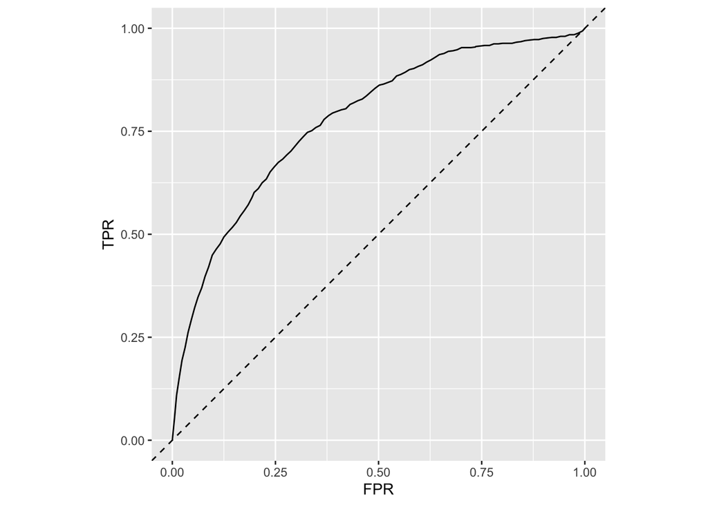

```r
ggplot(roc, aes(x = FPR, y = TPR)) +
  geom_line() +
  geom_abline(lty = "dashed") +
  coord_fixed()
```

And now we get the AUC value:

```r
validation_info$area_under_roc()
```

```
## [1] 0.7785043
```

# 5 Checking the model on the `testing` set

> **Task - 15 mins**

> Alright, over to you, let’s apply our fitted logistic regression model `logreg_model` to the `testing` data to see how it performs on unseen data! You will need to:
> - add `scaled_age` and `scaled_essay_length` variables to `testing` (NB use the `scaling_values` computed above from `training` for this, as this would be part of the specification of the model in production)
> - assemble the features together into a single `features` vector column
> - get validation information using `logreg_model` on `testing`
> - plot the ROC curve
> - get the AUC value

> From this limited comparison (cross-validation would be better), do you find any evidence of overfitting?

> **Solution**

> ```r
> testing <- testing %>%
>   mutate(
>     scaled_age = (age - !!scaling_values$mean_age) / !!scaling_values$sd_age,
>     scaled_essay_length = (essay_length - !!scaling_values$mean_essay_length ) / !!scaling_values$sd_essay_length
>   ) %>%
>   compute("testing")
>
> testing <- testing %>%
>   ft_vector_assembler(
>     input_cols = c("scaled_age", "scaled_essay_length", "drinks_encoded", "drugs_encoded", "status_encoded"),
>     output_col = "features"
>   ) %>%
>   compute("training")
>
> validation_info_test <- ml_evaluate(logreg_model, testing)
> validation_info_test
> ```

> ```
> ## BinaryLogisticRegressionSummaryImpl
> ##  Access the following via `$` or `ml_summary()`.
> ##  - features_col()
> ##  - label_col()
> ##  - predictions()
> ##  - probability_col()
> ##  - area_under_roc()
> ##  - f_measure_by_threshold()
> ##  - pr()
> ##  - precision_by_threshold()
> ##  - recall_by_threshold()
> ##  - roc()
> ##  - prediction_col()
> ##  - accuracy()
> ##  - f_measure_by_label()
> ##  - false_positive_rate_by_label()
> ##  - labels()
> ##  - precision_by_label()
> ##  - recall_by_label()
> ##  - true_positive_rate_by_label()
> ##  - weighted_f_measure()
> ##  - weighted_false_positive_rate()
> ##  - weighted_precision()
> ##  - weighted_recall()
> ##  - weighted_true_positive_rate()
> ```

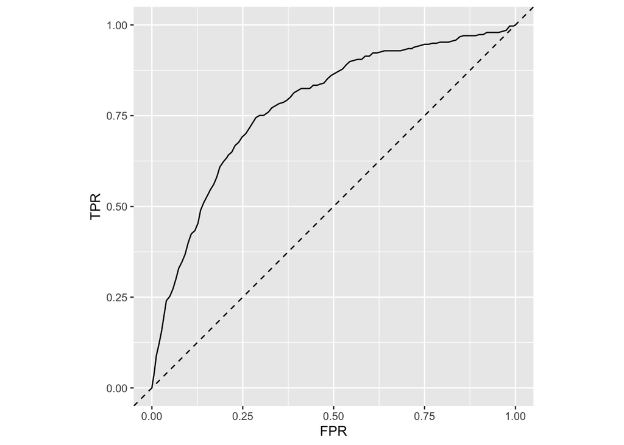

> ```r
> roc <- validation_info_test$roc() %>%
>   collect()
>
> ggplot(roc, aes(x = FPR, y = TPR)) +
>   geom_line() + geom_abline(lty = "dashed") +
>   coord_fixed()
> ```

> ```r
> validation_info_test$area_under_roc()
> ```

> ```
> ## [1] 0.7777583
> ```

> The AUC value is reasonably close to that obtained from `training`, so there’s no evidence of overfitting.